# Informe Clínica de Fertilidad

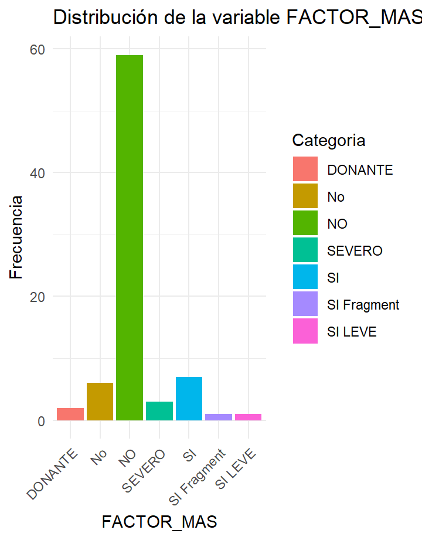

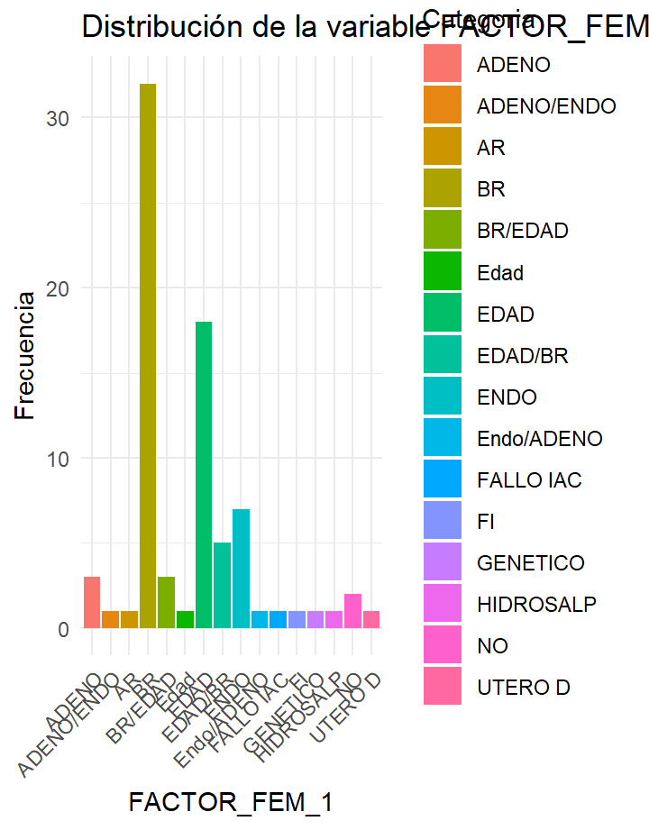

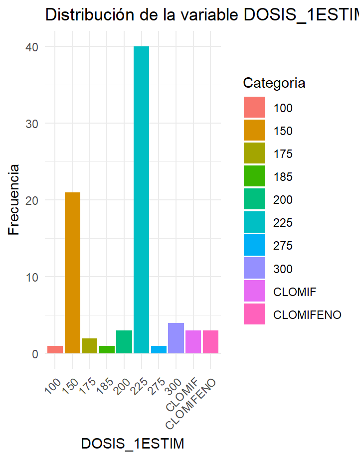

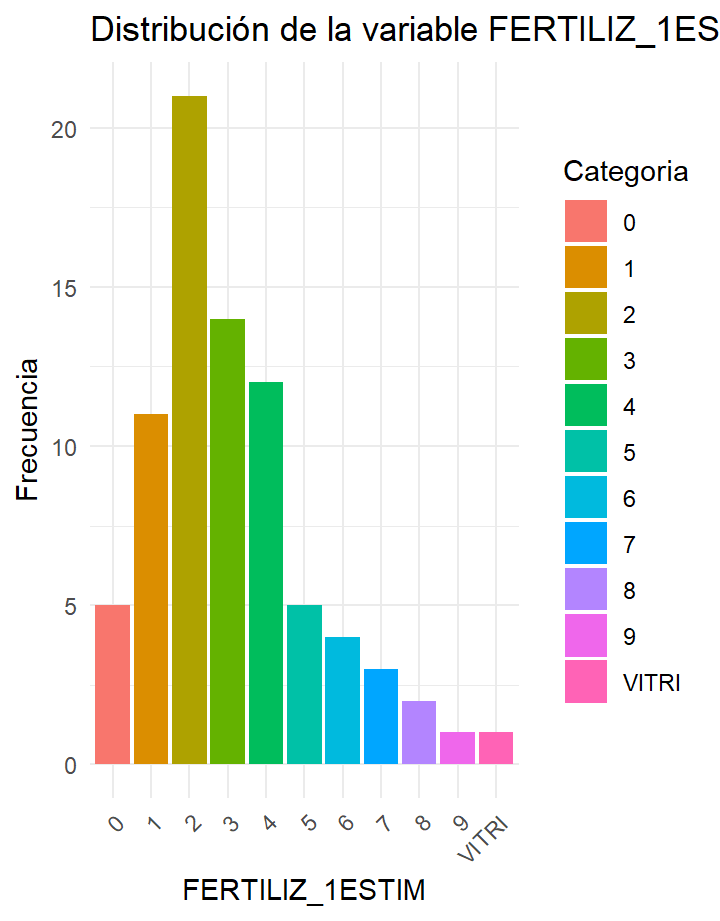

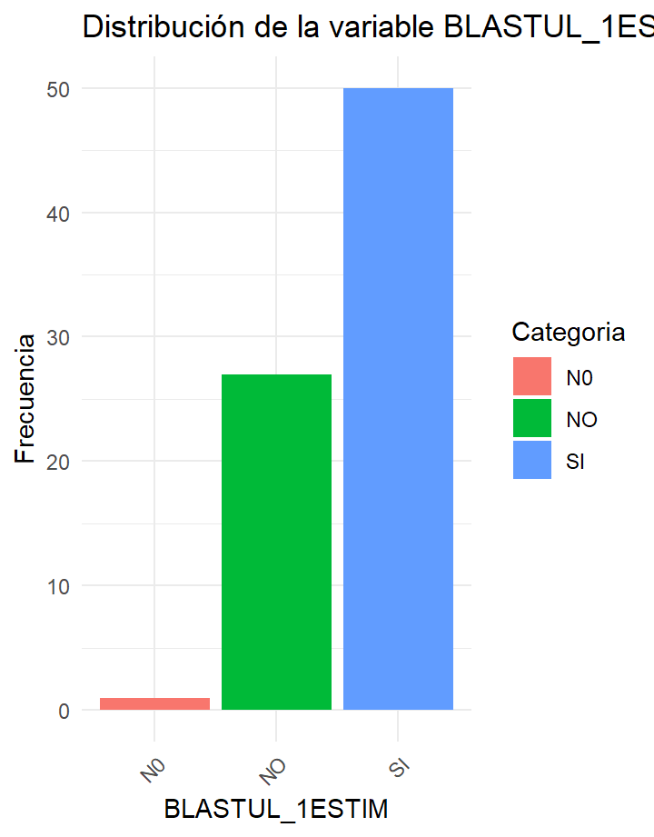

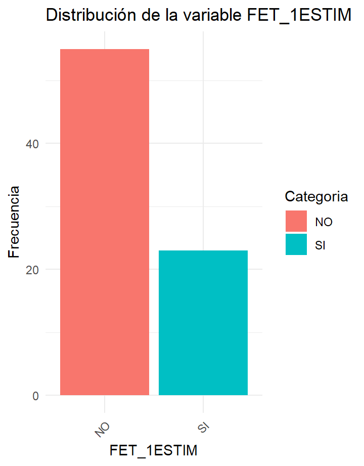

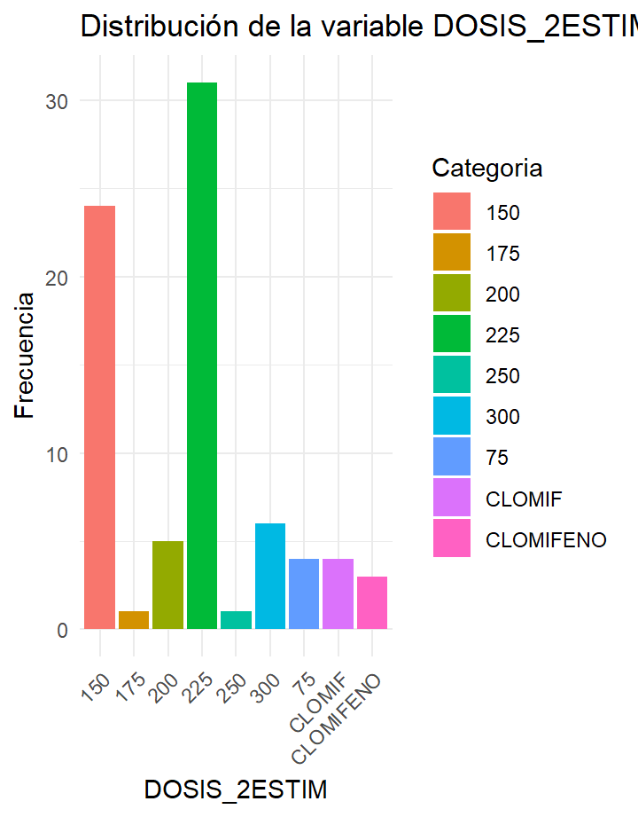

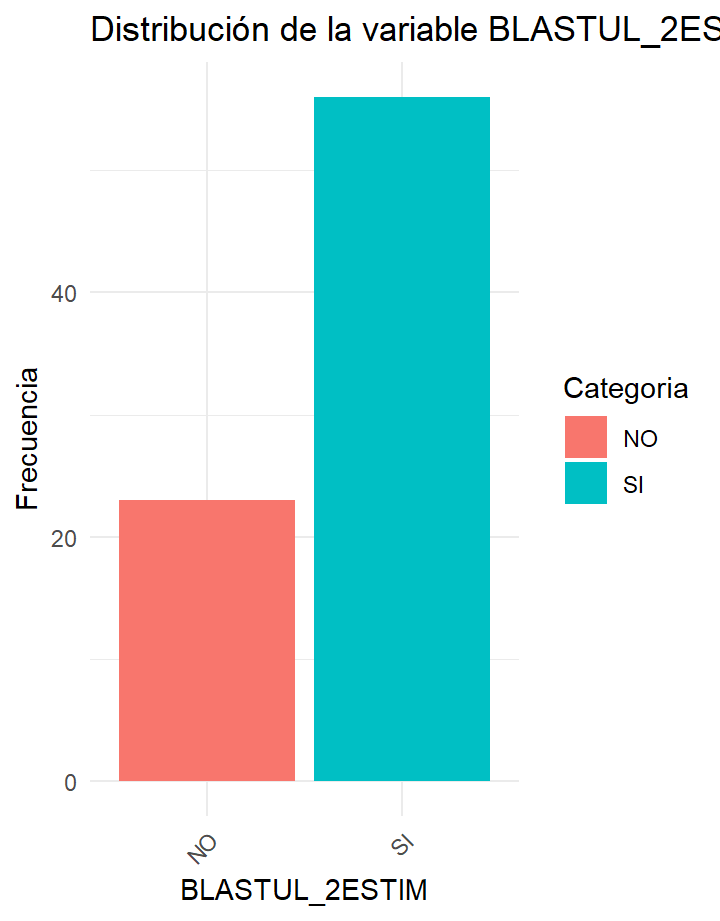

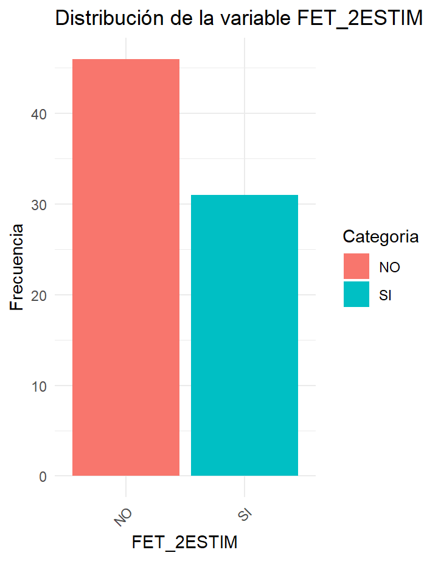

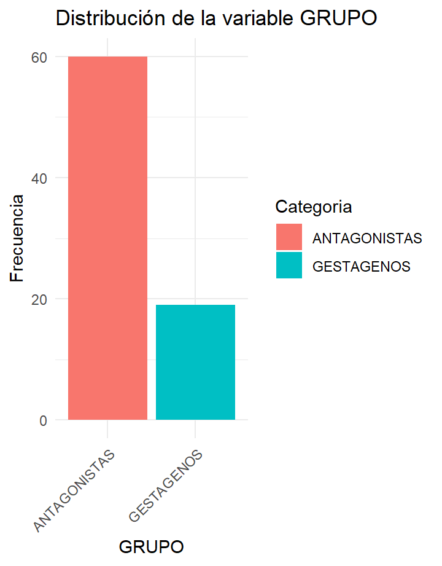

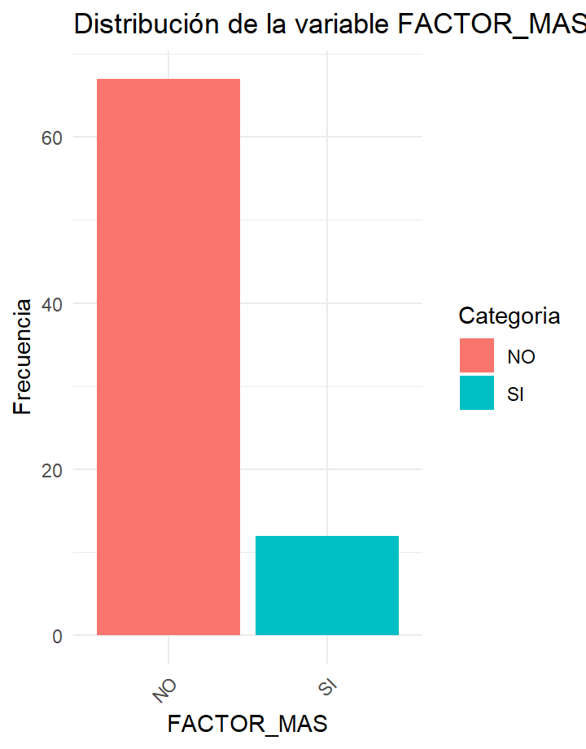

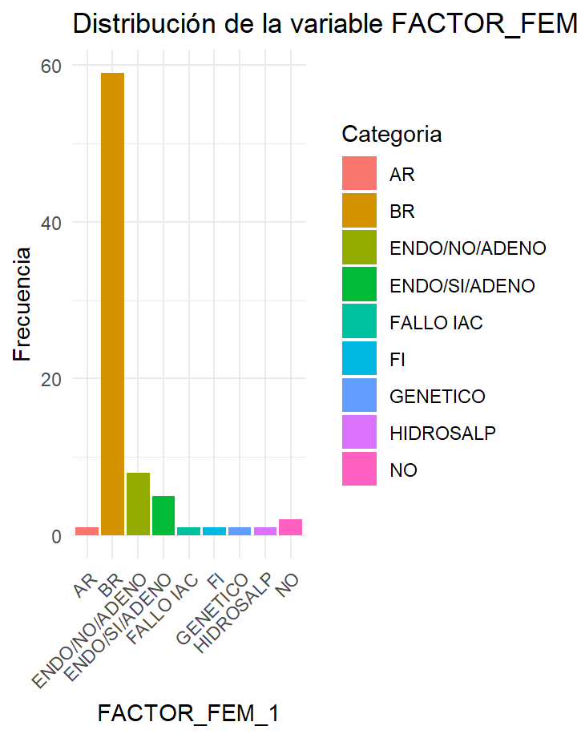

[17 more figures not shown]

# Organización de los .xlsx

## ## Column 1

### División del fichero original

El fichero `.xlsx` dado para esta práctica POSTsenta dos páginas. Cada una de estas páginas rePOSTsenta un grupo, **Antagonistas** o **Gestágenos**, para cada grupo se tienen una serie de variables comunes, y unos parámetros correspondientes a la **primera estimulación** y la **segunda estimulación**.

El objetivo entonces de este apartado será manipular este fichero `.xlsx` para convertirlo en diversos ficheros `.csv`, formato con el cual es más fácil trabajar en R. Se ha dividido entonces el fichero original en **6 ficheros**:

- Un total de 3 ficheros correspondientes al grupo de **Antagonistas**. Uno para las muestras de las variables de primera estimulación, otro para las de segunda estimulación, y uno para las variables comunes a ambos.
- Un total de 3 ficheros correspondientes al grupo de **Gestágenos**. Uno para las muestras de las variables de primera estimulación, otro para las de segunda estimulación, y uno para las variables comunes a ambos.

### Manipulación del nombre de las variables

Este procedimiento nos deja una serie de ficheros `.csv` con nombres de variables que no ayudan a distinguir entre la primera y la segunda estimulación. Es por esto que el siguiente paso será **manipular los nombres de las variables**, los cambios realizados son los siguientes:

- Adición del sufijo **1ESTIM** para las variables de primera estimulación.
- Adición del sufijo **2ESTIM** para las variables de segunda estimulación.
- Cambio de los caracteres **“.”**, **“-”**, **“/”** a **“_“** para evitar errores de referencia en el código.

## ## Column 2

### Antagonistas.csv

|  | EDAD | AFC | AMH | FACTOR_MAS | FACTOR_FEM_1 | BMI | DIAS_1ESTIM | DOSIS_1ESTIM | HMG_1ESTIM | Nº_OVO_1ESTIM | MII_1ESTIM | FERTILIZ_1ESTIM | BT_AA_1ESTIM | CONG_1ESTIM | BLASTUL_1ESTIM | FET_1ESTIM | DIAS_2ESTIM | DOSIS_2ESTIM | HMG_2ESTIM | Nº_OVO_2ESTIM | MII_2ESTIM | FERTILIZ_2ESTIM | BT_AA_2ESTIM | CONG_2ESTIM | BLASTUL_2ESTIM | FET_2ESTIM | GRUPO |
| --- | --- | --- | --- | --- | --- | --- | --- | --- | --- | --- | --- | --- | --- | --- | --- | --- | --- | --- | --- | --- | --- | --- | --- | --- | --- | --- | --- |
| 1 | 43 | 7 |  | NO | EDAD | 23 | 9 | 175 | 75 | 2 | 2 | 1 | 1 | 1 | SI | SI | 10 | 225 | 75 | 9 | 6 | 4 | 1 | 1 | SI |  | ANTAGONISTAS |
| 2 | 38 | 6 |  | NO | ADENO | 26 | 8 | 225 | 75 | 7 | 4 | 3 | 0 | 2 | SI | SI | 9 | 225 | 75 | 5 | 4 | 4 | 2 | 4 | SI | NO | ANTAGONISTAS |
| 3 | 34 | 4 | 0.6 | NO | BR | 21 | 11 | 225 | 75 | 3 | 2 | 1 | 1 | 1 | SI | SI | 12 | 200 | 75 | 7 | 6 | 3 | 2 | 2 | SI | SI | ANTAGONISTAS |
| 4 | 32 | 6 |  | NO | BR | 23 | 9 | 225 |  | 6 | 6 | VITRI |  |  |  |  | 7 | 225 |  | 10 | 5 | 5 | 2 | 4 | SI | NO | ANTAGONISTAS |
| 5 | 43 | 7 |  | NO | EDAD | 23 | 10 | 225 | 75 | 11 | 8 | 3 | 0 | 0 | NO | NO | 10 | 200 | 75 | 6 | 6 | 5 | 0 | 0 | NO | NO | ANTAGONISTAS |
| 6 | 36 | 5 |  | SI | BR | 22 | 12 | 225 |  | 4 | 4 | 2 | 0 | 0 | SI | NO | 13 | 225 |  | 9 | 6 | 3 | 0 | 0 | NO | NO | ANTAGONISTAS |
| 7 | 39 | 6 |  | NO | Edad | 26 | 13 | 225 | 75 | 5 | 4 | 3 | 0 | 0 | NO | NO | 15 | 225 | 75 | 4 | 4 | 4 | 1 | 1 | SI | NO | ANTAGONISTAS |
| 8 | 40 |  | 1.45 | NO | ENDO | 24 | 8 | 150 | 150 | 5 | 4 | 3 | 1 | 2 | SI | SI | 14 | 150 | 150 | 8 | 7 | 6 | 2 | 2 | SI | SI | ANTAGONISTAS |
| 9 | 34 | 5 |  | SI | BR | 23 | 12 | 225 |  | 5 | 5 | 3 | 0 | 0 | SI | NO | 12 | 225 |  | 5 | 4 | 1 | 0 | 1 | SI | SI | ANTAGONISTAS |
| 10 | 38 | 10 |  | SEVERO | ENDO | 21 | 8 | 300 | 150 | 5 | 5 | 4 | 2 | 2 | SI | SI | 12 | 300 | 150 | 13 | 9 | 9 | 0 | 0 | NO | NO | ANTAGONISTAS |

[output cut: 50 more lines]

### Gestagenos.csv

|  | EDAD | AFC | AMH | FACTOR_MAS | FACTOR_FEM_1 | BMI | DIAS_1ESTIM | DOSIS_1ESTIM | HMG_1ESTIM | Nº_OVO_1ESTIM | MII_1ESTIM | FERTILIZ_1ESTIM | BT_AA_1ESTIM | CONG_1ESTIM | BLASTUL_1ESTIM | FET_1ESTIM | DIAS_2ESTIM | DOSIS_2ESTIM | HMG_2ESTIM | Nº_OVO_2ESTIM | MII_2ESTIM | FERTILIZ_2ESTIM | BT_AA_2ESTIM | CONG_2ESTIM | BLASTUL_2ESTIM | FET_2ESTIM | GRUPO |
| --- | --- | --- | --- | --- | --- | --- | --- | --- | --- | --- | --- | --- | --- | --- | --- | --- | --- | --- | --- | --- | --- | --- | --- | --- | --- | --- | --- |
| 1 | 36 | 4 | 0.18 | NO | BR | 16 | 8 | CLOMIFENO | 150 | 4 | 2 | 1 | 0 | 0 | NO | NO | 9 | CLOMIF | 150 | 6 | 6 | 6 | 3 | 3 | SI | SI | GESTAGENOS |
| 2 | 45 | 3 |  | NO | EDAD | 29 | 10 | 150 | 150 | 2 | 2 | 2 | 0 | 0 | NO | NO | 14 | 225 | 150 | 4 | 3 | 2 | 1 | 1 | SI | NO | GESTAGENOS |
| 3 | 35 | 5 | 1.6 | NO | FI | 23 | 9 | 150 | 150 | 2 | 2 | 2 | 1 | 1 | SI | SI | 12 | 150 | 150 | 5 | 5 | 4 | 2 | 2 | SI | SI | GESTAGENOS |
| 4 | 35 | 5 | 0.63 | NO | ENDO | 24 | 10 | 200 | 75 | 5 | 5 | 3 | 0 | 2 | SI | NO | 14 | 75 | 225 | 3 | 3 | 3 | 3 | 3 | SI | SI | GESTAGENOS |
| 5 | 36 | 4 |  | NO | BR | 26 | 8 | 225 | 75 | 2 | 2 | 2 | 1 | 2 | SI | SI | 12 | 300 | 150 | 4 | 3 | 2 | 1 | 1 | SI | SI | GESTAGENOS |
| 6 | 38 | 5 |  | NO | ENDO | 21 | 9 | 225 | 75 | 10 | 9 | 5 | 2 | 2 | SI | NO | 10 | 225 | 75 | 7 | 6 | 6 | 2 | 2 | SI | NO | GESTAGENOS |
| 7 | 33 | 3 |  | NO | BR | 23 | 8 | 100 | 75 | 2 | 2 | 2 | 0 | 0 | NO | NO | 11 | CLOMIF | 150 | 4 | 4 | 3 | 1 | 1 | SI | SI | GESTAGENOS |
| 8 | 34 | 6 | 1.43 | No | Endo/ADENO | 24 | 14 | 225 | 75 | 5 | 3 | 2 | 0 | 1 | SI | NO | 13 | 225 |  | 6 | 6 | 5 | 3 | 3 | SI | NO | GESTAGENOS |
| 9 | 33 | 14 |  | NO | GENETICO | 22 | 6 | 225 | 75 | 4 | 4 | 3 | 0 | 0 | N0 | NO | 10 | 150 | 150 | 13 | 9 | 8 | 5 | 7 | SI | SI | GESTAGENOS |
| 10 | 40 | 14 |  | NO | EDAD | 24 | 8 | 225 | 75 | 8 | 4 | 2 | 0 | 0 | NO | NO | 11 | 150 | 150 | 7 | 6 | 4 | 3 | 4 | SI | SI | GESTAGENOS |

[output cut: 9 more lines]

### Combinado.csv

|  | EDAD | AFC | AMH | FACTOR_MAS | FACTOR_FEM_1 | BMI | DIAS_1ESTIM | DOSIS_1ESTIM | HMG_1ESTIM | Nº_OVO_1ESTIM | MII_1ESTIM | FERTILIZ_1ESTIM | BT_AA_1ESTIM | CONG_1ESTIM | BLASTUL_1ESTIM | FET_1ESTIM | DIAS_2ESTIM | DOSIS_2ESTIM | HMG_2ESTIM | Nº_OVO_2ESTIM | MII_2ESTIM | FERTILIZ_2ESTIM | BT_AA_2ESTIM | CONG_2ESTIM | BLASTUL_2ESTIM | FET_2ESTIM | GRUPO |
| --- | --- | --- | --- | --- | --- | --- | --- | --- | --- | --- | --- | --- | --- | --- | --- | --- | --- | --- | --- | --- | --- | --- | --- | --- | --- | --- | --- |
| 1 | 43 | 7 |  | NO | EDAD | 23 | 9 | 175 | 75 | 2 | 2 | 1 | 1 | 1 | SI | SI | 10 | 225 | 75 | 9 | 6 | 4 | 1 | 1 | SI |  | ANTAGONISTAS |
| 2 | 38 | 6 |  | NO | ADENO | 26 | 8 | 225 | 75 | 7 | 4 | 3 | 0 | 2 | SI | SI | 9 | 225 | 75 | 5 | 4 | 4 | 2 | 4 | SI | NO | ANTAGONISTAS |
| 3 | 34 | 4 | 0.6 | NO | BR | 21 | 11 | 225 | 75 | 3 | 2 | 1 | 1 | 1 | SI | SI | 12 | 200 | 75 | 7 | 6 | 3 | 2 | 2 | SI | SI | ANTAGONISTAS |
| 4 | 32 | 6 |  | NO | BR | 23 | 9 | 225 |  | 6 | 6 | VITRI |  |  |  |  | 7 | 225 |  | 10 | 5 | 5 | 2 | 4 | SI | NO | ANTAGONISTAS |
| 5 | 43 | 7 |  | NO | EDAD | 23 | 10 | 225 | 75 | 11 | 8 | 3 | 0 | 0 | NO | NO | 10 | 200 | 75 | 6 | 6 | 5 | 0 | 0 | NO | NO | ANTAGONISTAS |
| 6 | 36 | 5 |  | SI | BR | 22 | 12 | 225 |  | 4 | 4 | 2 | 0 | 0 | SI | NO | 13 | 225 |  | 9 | 6 | 3 | 0 | 0 | NO | NO | ANTAGONISTAS |
| 7 | 39 | 6 |  | NO | Edad | 26 | 13 | 225 | 75 | 5 | 4 | 3 | 0 | 0 | NO | NO | 15 | 225 | 75 | 4 | 4 | 4 | 1 | 1 | SI | NO | ANTAGONISTAS |
| 8 | 40 |  | 1.45 | NO | ENDO | 24 | 8 | 150 | 150 | 5 | 4 | 3 | 1 | 2 | SI | SI | 14 | 150 | 150 | 8 | 7 | 6 | 2 | 2 | SI | SI | ANTAGONISTAS |
| 9 | 34 | 5 |  | SI | BR | 23 | 12 | 225 |  | 5 | 5 | 3 | 0 | 0 | SI | NO | 12 | 225 |  | 5 | 4 | 1 | 0 | 1 | SI | SI | ANTAGONISTAS |
| 10 | 38 | 10 |  | SEVERO | ENDO | 21 | 8 | 300 | 150 | 5 | 5 | 4 | 2 | 2 | SI | SI | 12 | 300 | 150 | 13 | 9 | 9 | 0 | 0 | NO | NO | ANTAGONISTAS |

[output cut: 69 more lines]

# Recodificación de Variables Categóricas

## ## Columna 1

### Planteamiento del problema

En este apartado se van a tratar las variables categóricas. Un paso muy importante para su tratamiento es la conversión de estas columnas al tipo de factor `factor`, sin embargo, antes de poder realizar este cambio, se deben manipular los valores de estas variables por las siguientes razones:

1. Hay valores que R toma como valores únicos, pero que realmentes son `typos` o errores de escritura que los profesionales de la salud tuvieron a la hora de hacer los datos. Por ejemplo, en `BLASTUL_1ESTIM`, el valor `N0` realmente se refiere a `NO`.
2. Se han introducido valores de cadena de texto en variables de naturaleza numérica. Este tipo de valores deben ser imputados para no perder la muestra y poder tratar la variable como numérica. Un ejemplo lo tendríamos en la variable `FERTILIZ_1ESTIM`, que muestra valores numéricos excepto una muestra, con un valor anómalo `VITRI`.
3. Por POSTferencia del personal clínico, se harán algunos cambios en la codificación de determinadas variables. Todos estos cambios serán detallados más adelante.

### Resumen de la solución

Para resolver los casos (1) y (3) se hará un cambio manual, indicando el anterior valor y el nuevo -esto se realizará con el paquete `dplyr`. Para el caso (2), se hará un cambio manual de los valores anómalos por `NA_character`, de esta forma estos valores se imputarán por medidas de tendencia central o de otra naturaleza numérica a la hora de imputar valores faltantes.

Se han hecho entonces estos cambios:

**Cambios para DOSIS Primera Estimulación** `CLOMIF` = NA_character, `CLOMIFENO` = NA_character

**Cambios para DOSIS Segunda Estimulación** `CLOMIF` = NA_character, `CLOMIFENO` = NA_character

**Cambios para FETILIZ Primera Estimulación** `VITRI` = NA_character

**Cambios para Factor Femenino** `Edad` = “BR”, `EDAD` = “BR”, `BR` = “BR”, `BR/EDAD` = “BR”, `EDAD/BR` = “BR”, `ADENO` = “ENDO/SI/ADENO”, `ADENO/ENDO` = “ENDO/SI/ADENO”, `Endo/ADENO` = “ENDO/SI/ADENO”, `ENDO` = “ENDO/NO/ADENO”, `UTERO D` = “ENDO/NO/ADENO”

**Cambios para Factor Masculino** `DONANTE` = “NO”, `No` = “NO”, `SEVERO` = “SI”,  
`SI Fragment` = “SI”, `SI LEVE` = “SI”

**Cambios para Blástula Primera Estimulación** `N0` = “NO”

## ## Column 2

#### Menú de gráficas generadas

- **PRE**. Se refiere a las gráficas correspondientes a las distribuciones de las variables categóricas antes de realizar la recodificación.
- **POST**. Se refiere a las gráficas correspondientes a las distribuciones de las variables categóricas después de realizar la recodificación.

### Factor Masculino - PRE

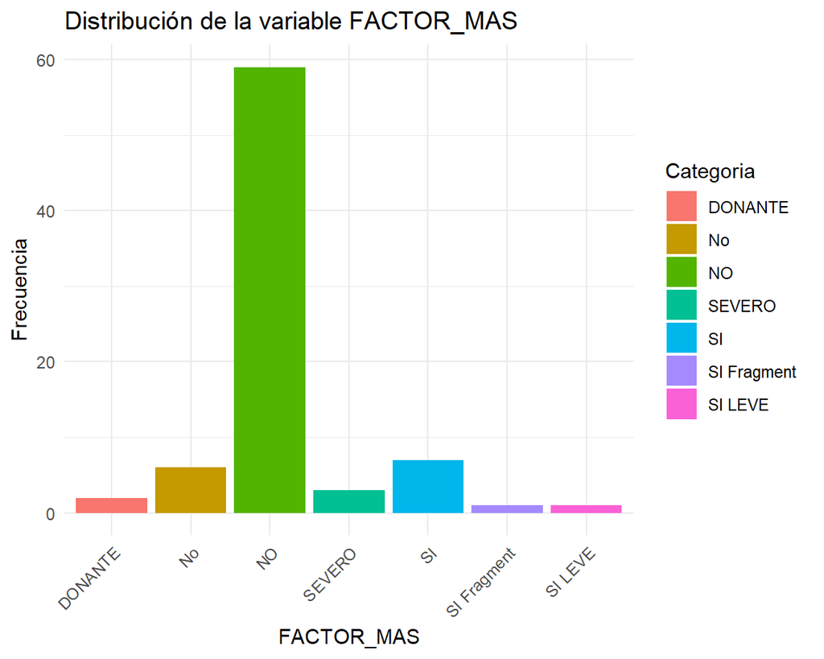

### Factor Femenino - PRE

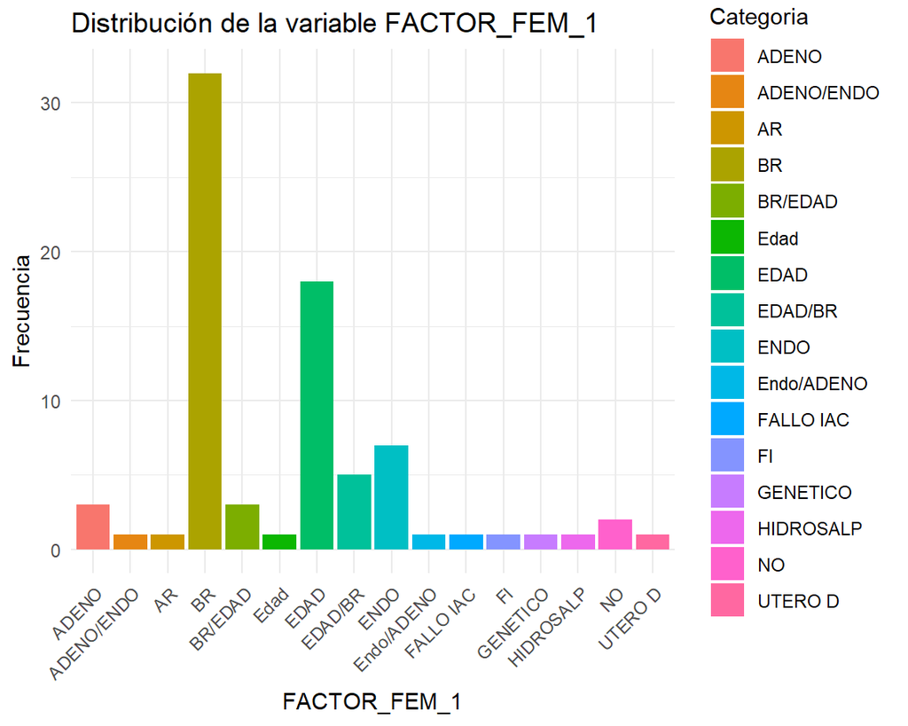

### Dosis 1ESTIM - PRE

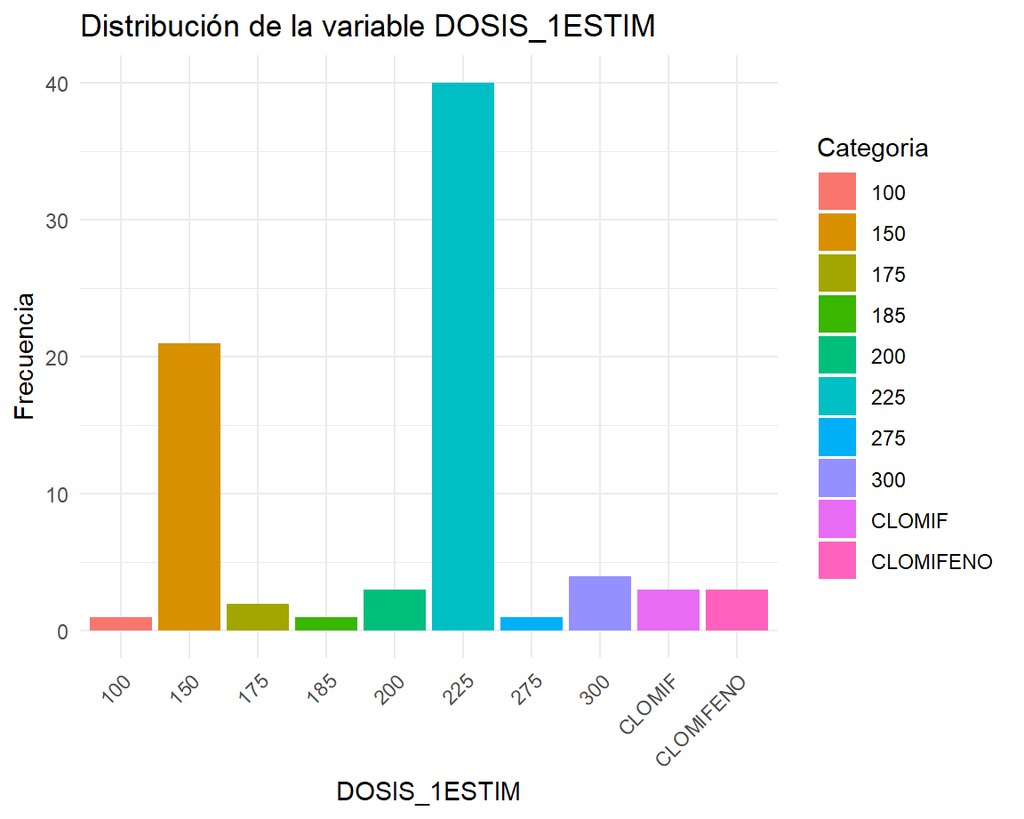

### Fertilización 1ESTIM - PRE

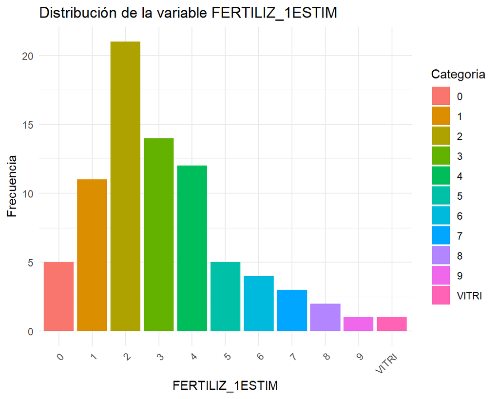

### Blastulación 1ESTIM - PRE

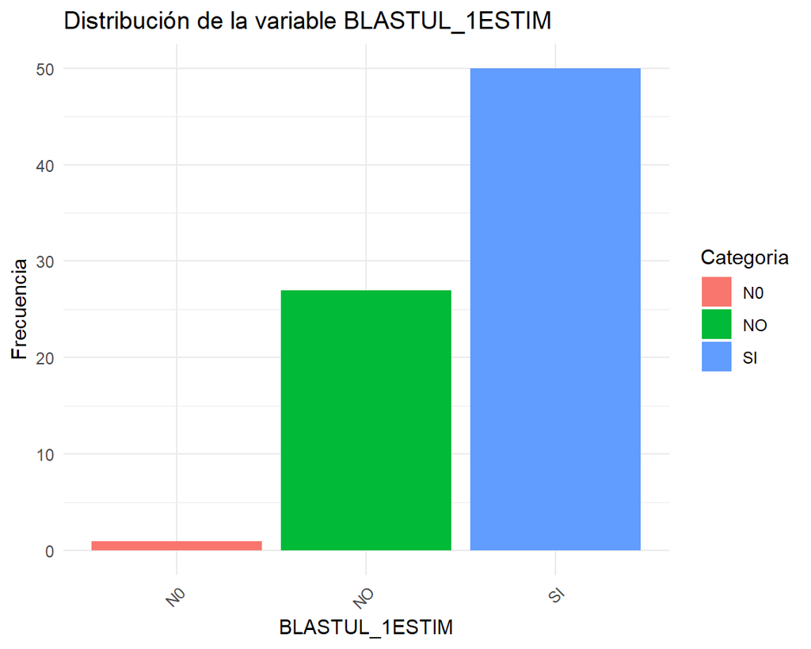

### Feto 1ESTIM - PRE

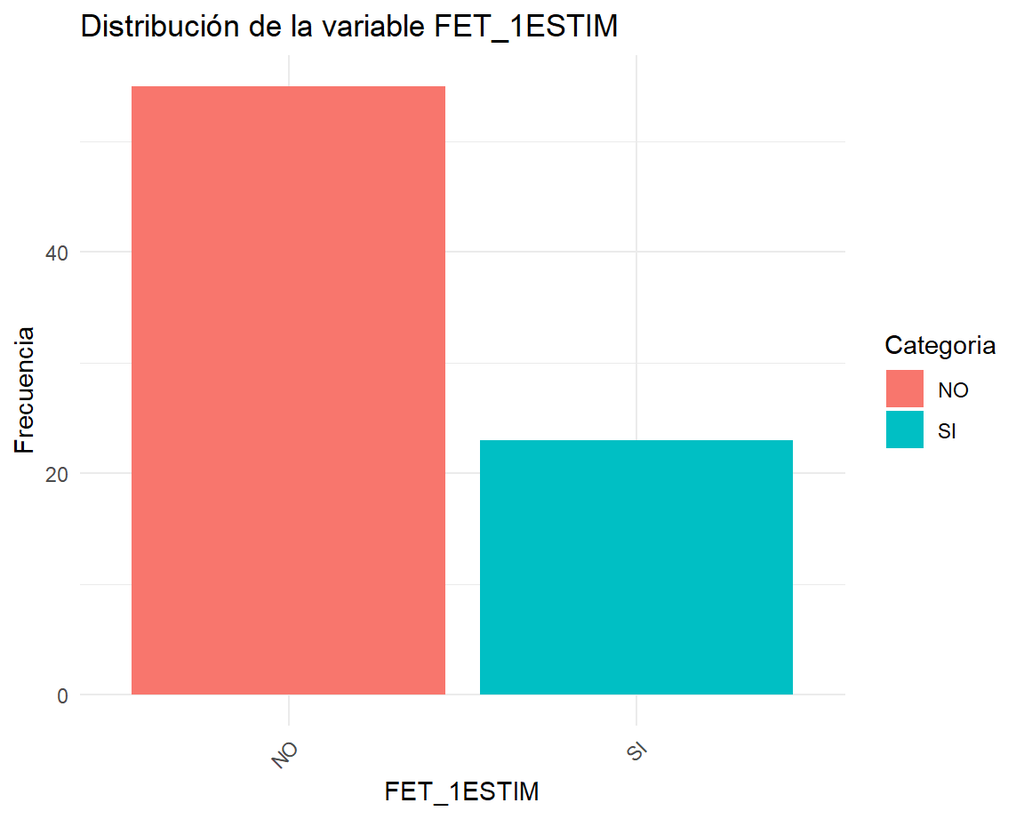

### Dosis 2ESTIM - PRE

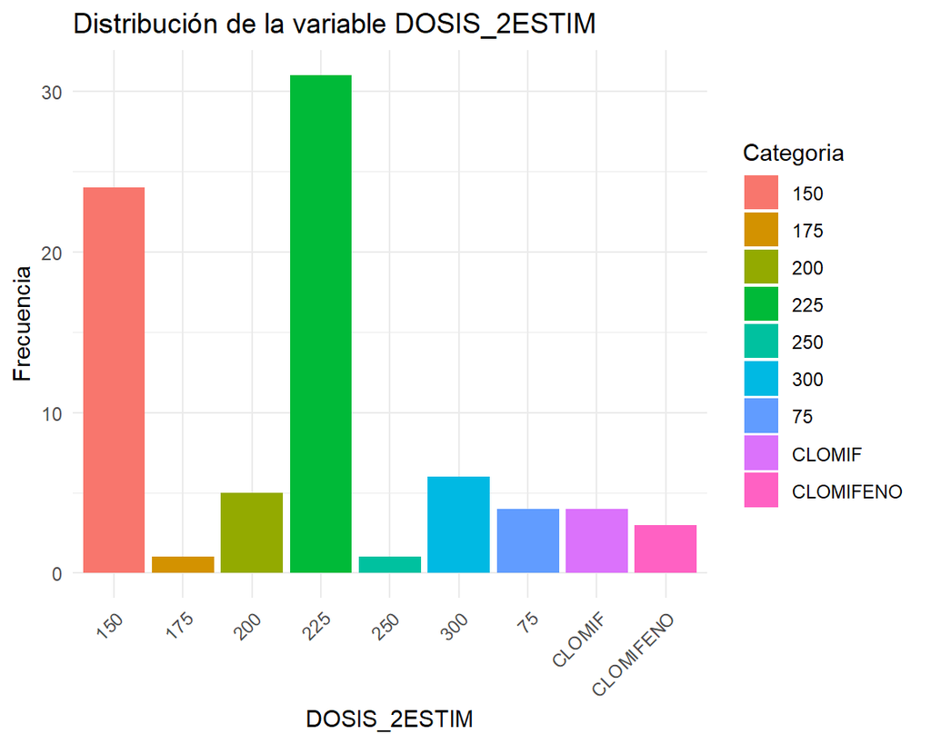

### Blastulación 2ESTIM - PRE

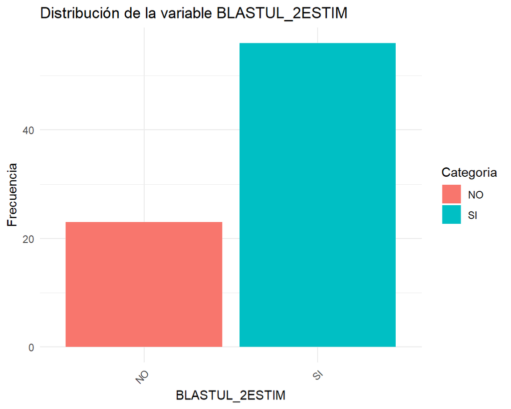

### Feto 2ESTIM - PRE

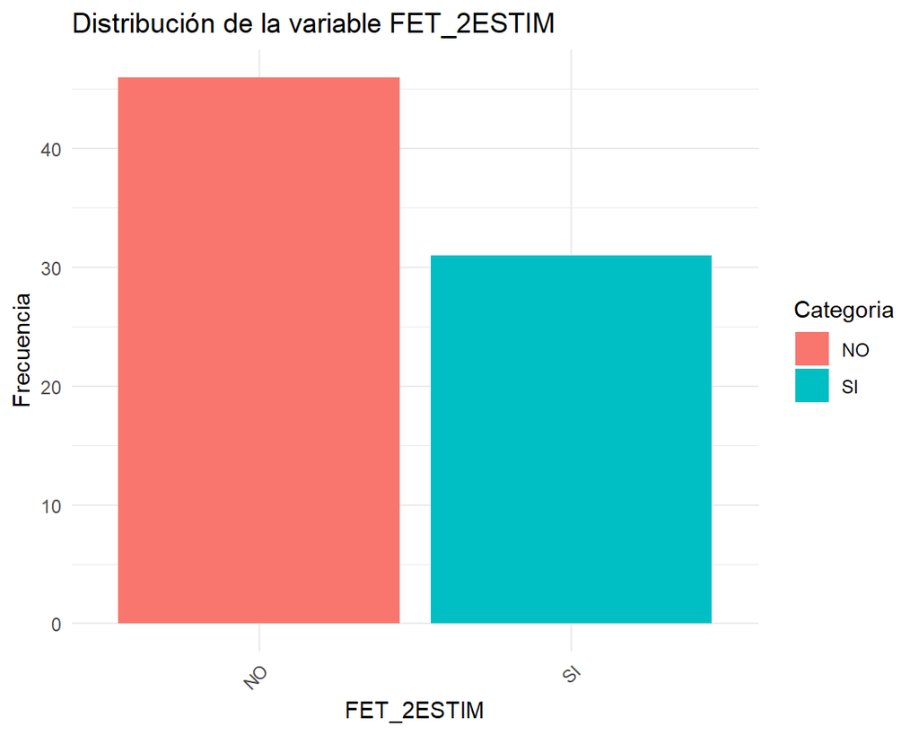

### Grupo - PRE

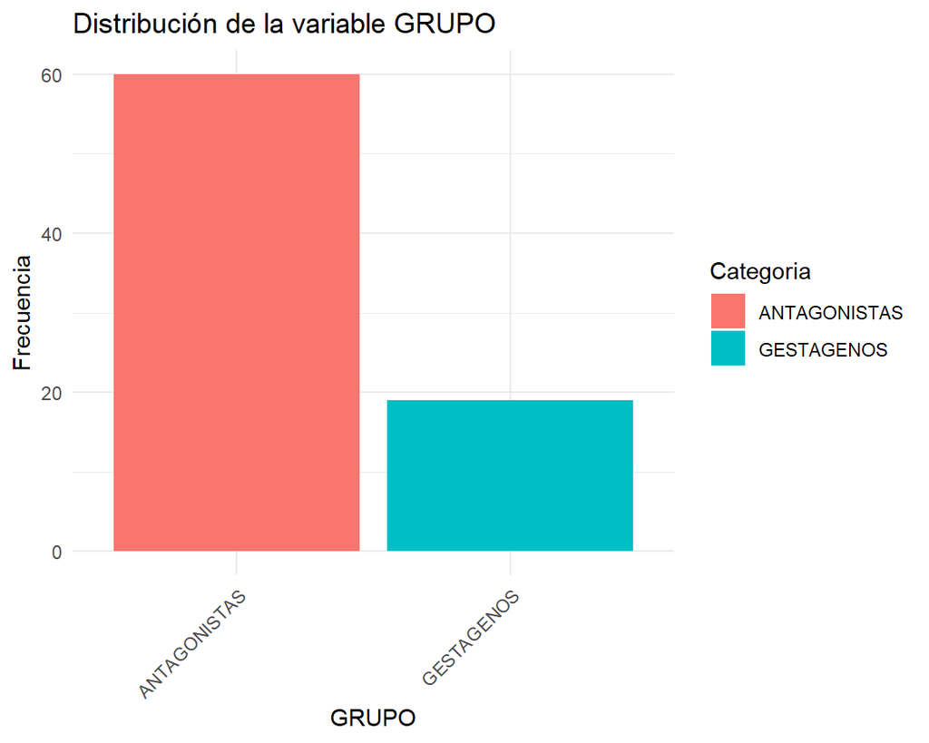

### Factor Masculino - POST

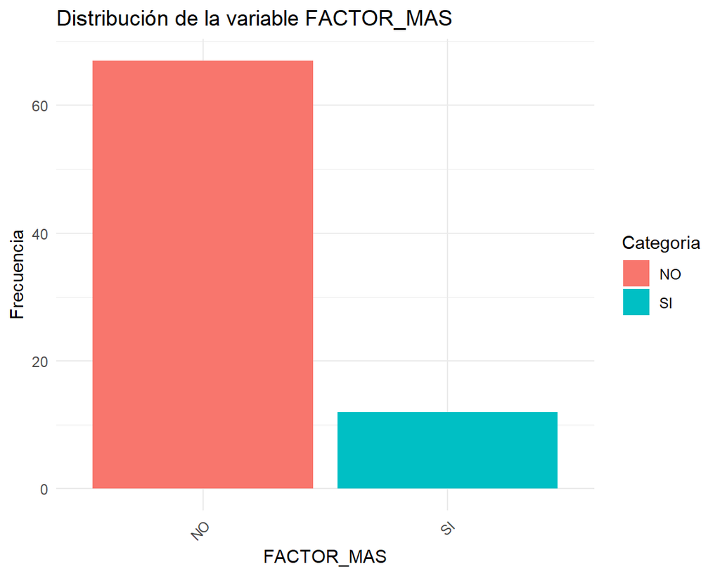

### Factor Femenino - POST

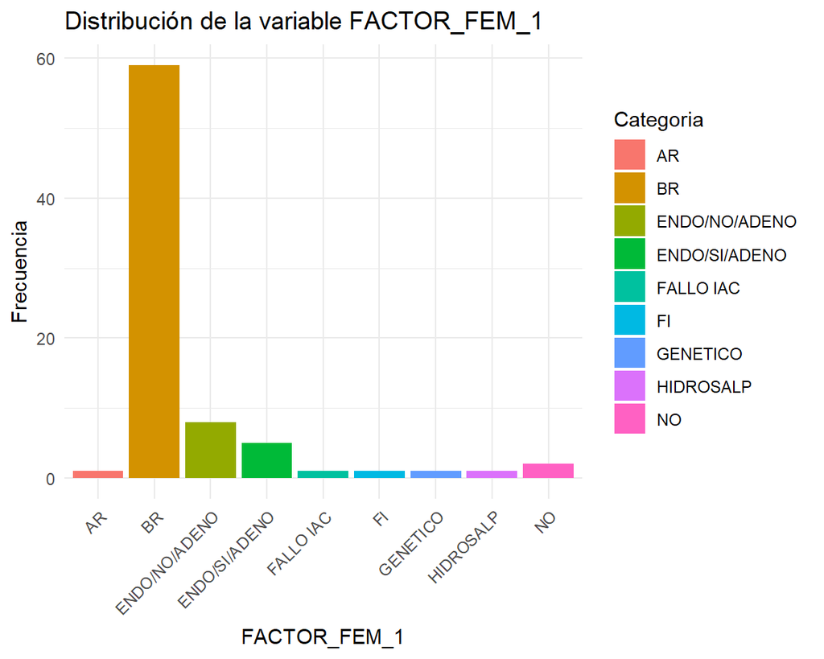

### Blastulación 1ESTIM - POST

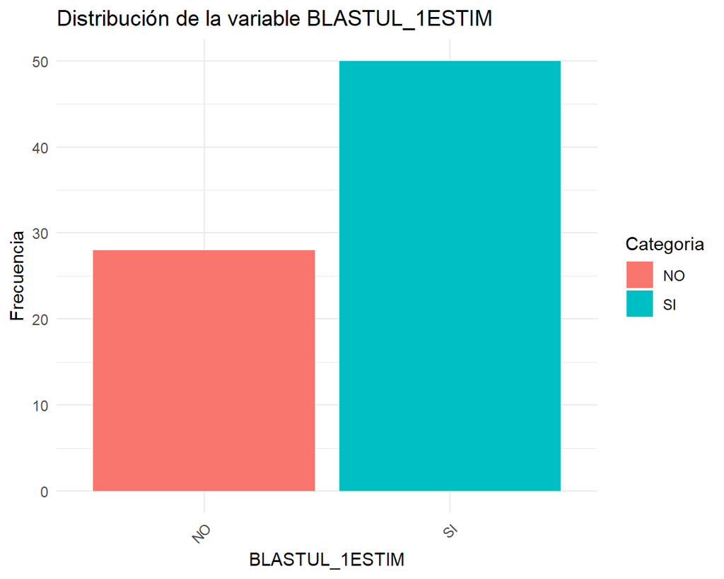

### Feto 1ESTIM - POST

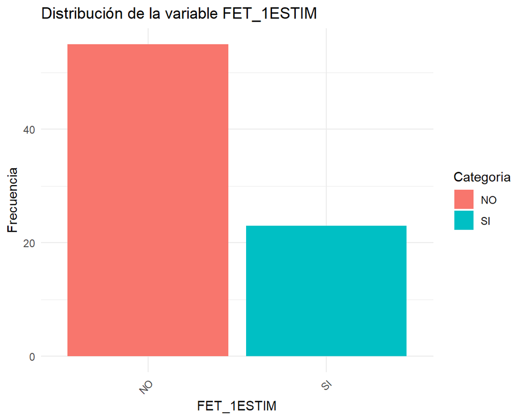

### Blastulación 2ESTIM - POST

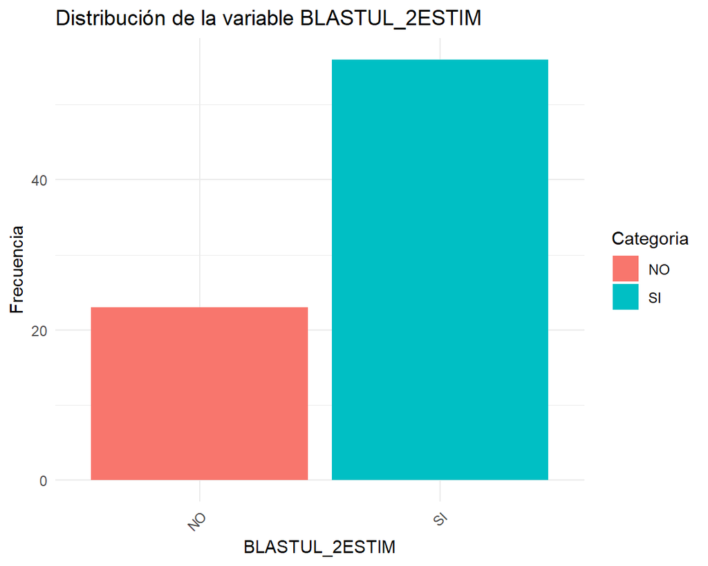

### Feto 2ESTIM - POST

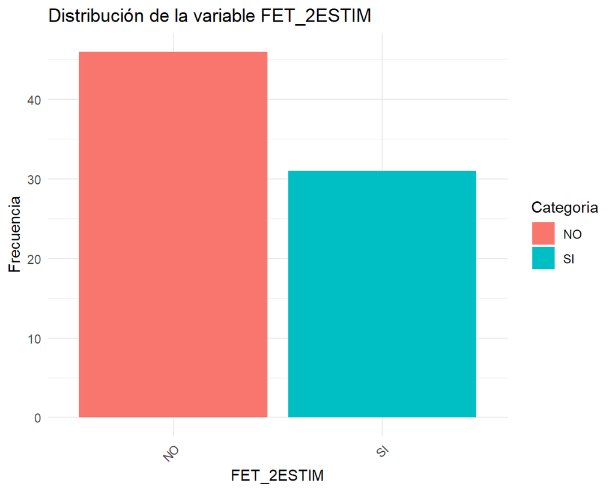

### Grupo - POST

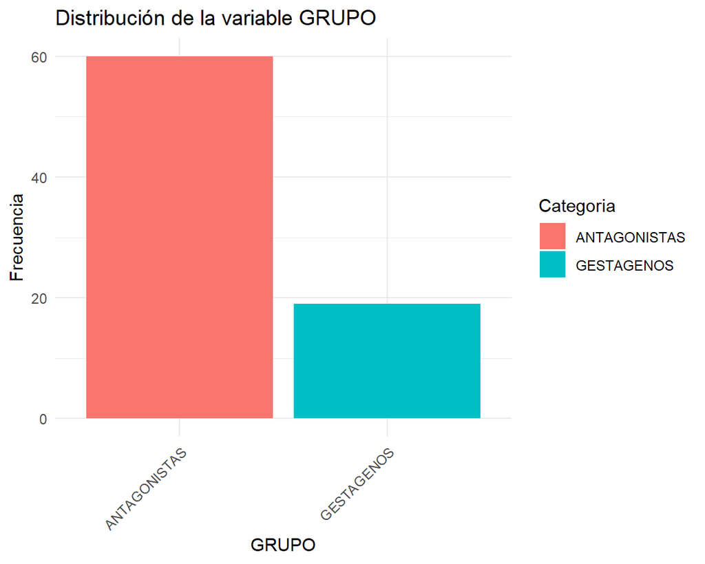

# Imputación de datos faltantes (NA)

## ## Column 1

### Planteamiento del problema

Como se pudo observar en el conjunto de datos (objeto `data.frame`) de la sección *“Organización de los .xlsx”*, nuestro dataset contiene una serie de valores faltantes o valores `NA`(*Not Avaiable*). Los conjuntos de datos clínicos tienen una gran cantidad de estos valores, sin embargo, al contener también una cantidad moderada de muestras, estos valores deben imputarse con medidas representativas de la columna para no perder información. Este paso es crucial para poder tener suficientes datos para poder aplicar modelos explicativos, predictivos, o hacer estadística.

- Para variables categóricas se ha elegido imputar con la moda (sustituir `NA` por el valor con mayor frecuencia de la columna).
- Para variables numéricas se ha tomado un acercamiento más cauteloso. Se explorarán los `boxplot` de cada columna, que representan medidas como la dispersión, media, mediana, IRQ o valores atípicos. Con esta información, se decidirá si imputar los valores `NA` con la media o la mediana.
- Variables que presenten más de la mitad de datos faltantes se tomarán como no representativas y se eliminará la columna.

### Resumen de la solución

- Se ha decidido imputar los valores `NA` de variables numéricas con la mediana.
- Se han imputado los valores `NA` de las variables categóricas con la moda.
- Se ha eliminado la columna `AMH` por su alto porcentaje de valores faltantes.

## ## Columna 2

#### Porcentaje de valores `NA` por variable

- La primera gráfica muestra en un gráfico de barras la cantidad de valores `NA` relativa al total de muestras por cada columna.
- La segunda gráfica muestra lo mismo, pero se puede notar que es después del procesamiento, ya que todos los valores `NA` han sido imputados.

### Distribución de valores NA - PRE

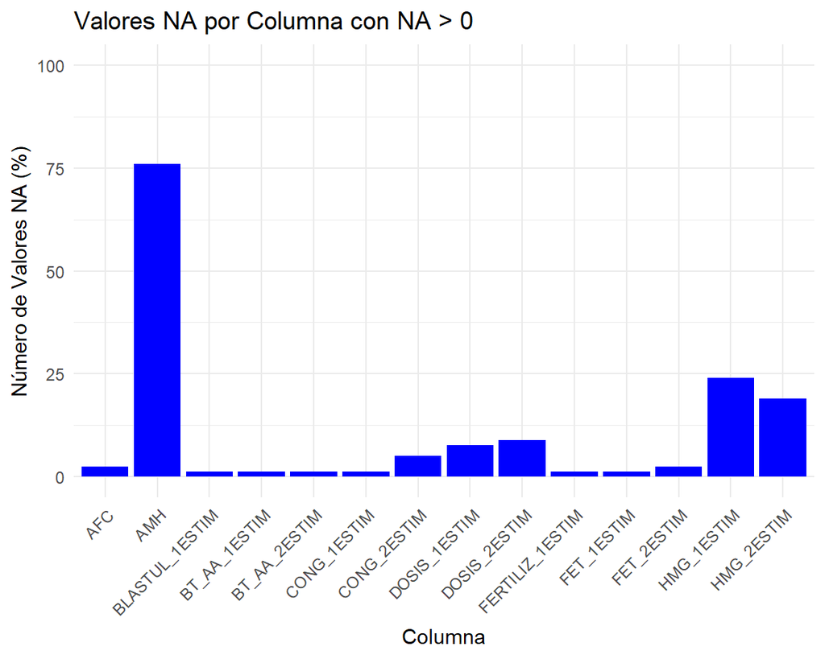

### Distribución de valores NA - POST

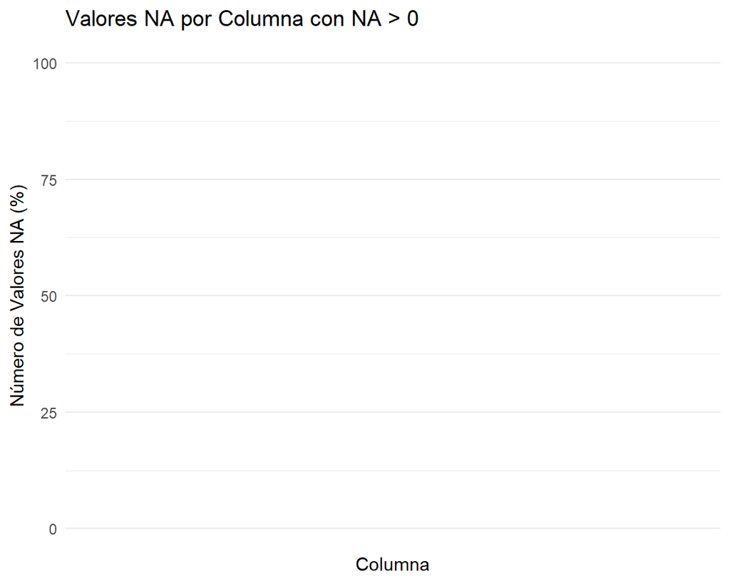

## ## Columna 3

#### Boxplots de las variables numéricas

Se muestran los gráficos de caja individuales de cada variable numérica del conjunto de datos. Después de una exhaustiva observación podemos ver que hay variables con un alto grado de dispersión o valores atípicos, es por esto que se ha decidido imputar los valores `NA` de variables numéricas con una medida de tendencia central más estable; la **mediana**.

### Boxplot de Recuento de Folículos Antrales

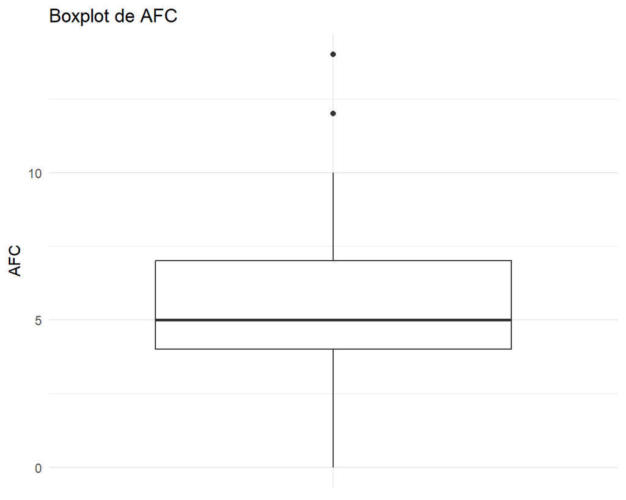

### Boxplot Dosis (1ESTIM)

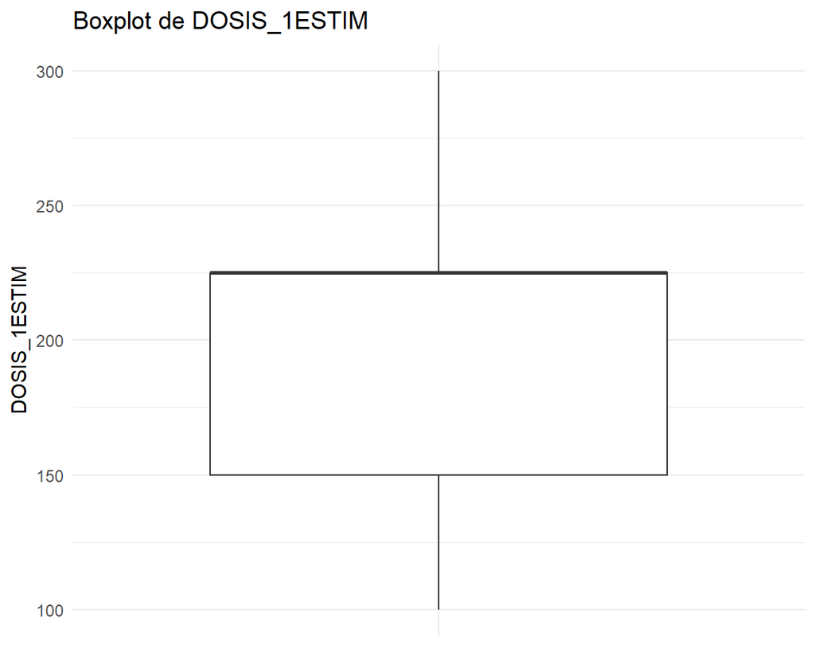

### Boxplot HMG (1ESTIM)

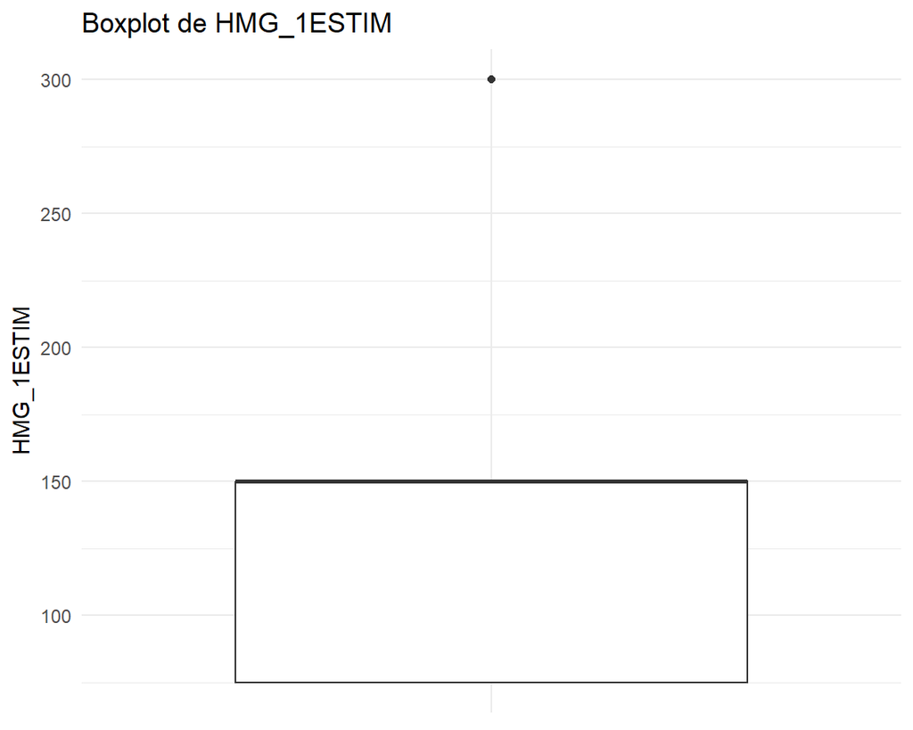

### Boxplot Fertilización (1ESTIM)

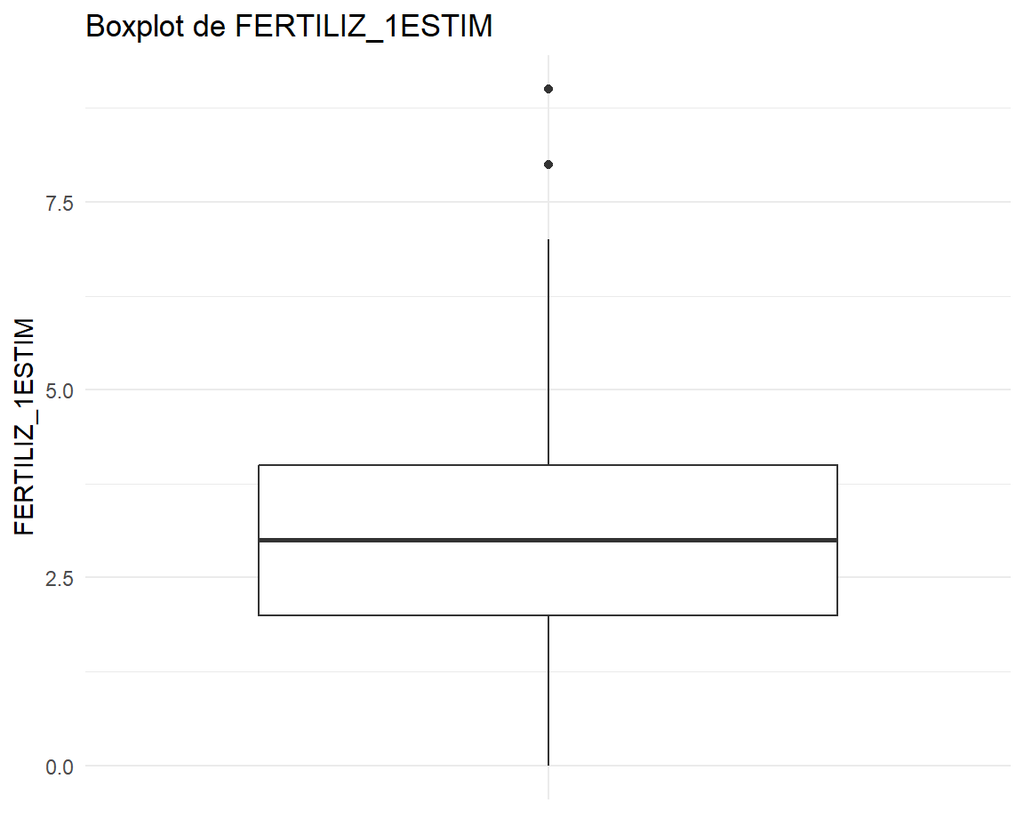

### Boxplot Número de Blastos de buena Calidad (1ESTIM)

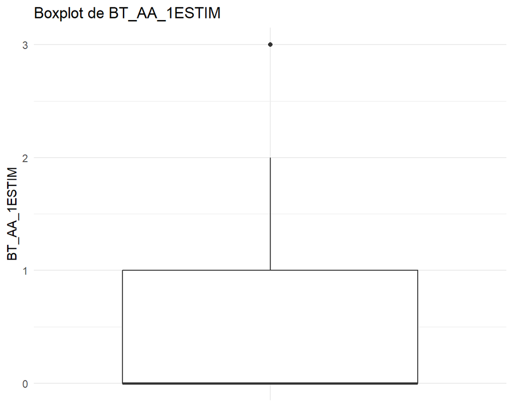

### Boxplot CONG (1ESTIM)

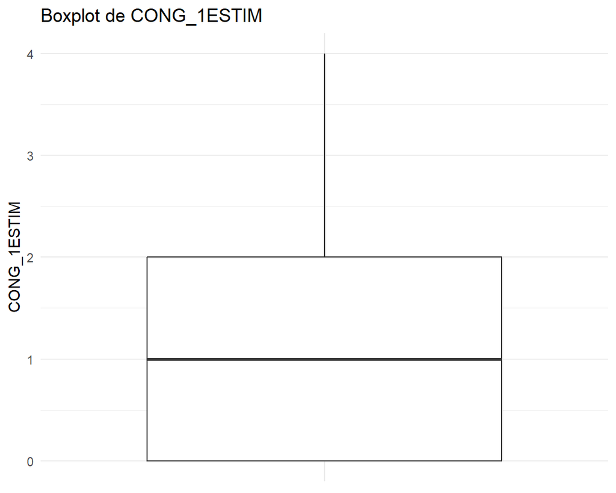

### Boxplot Dosis (2ESTIM)

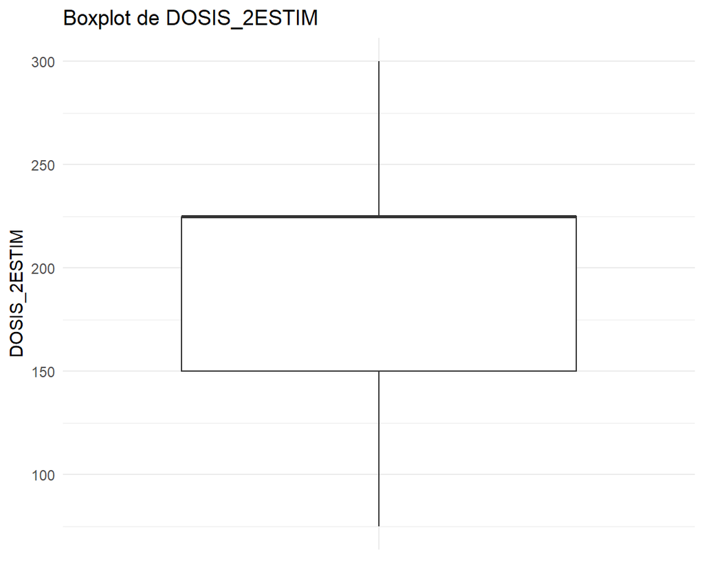

### Boxplot HMG (2ESTIM)

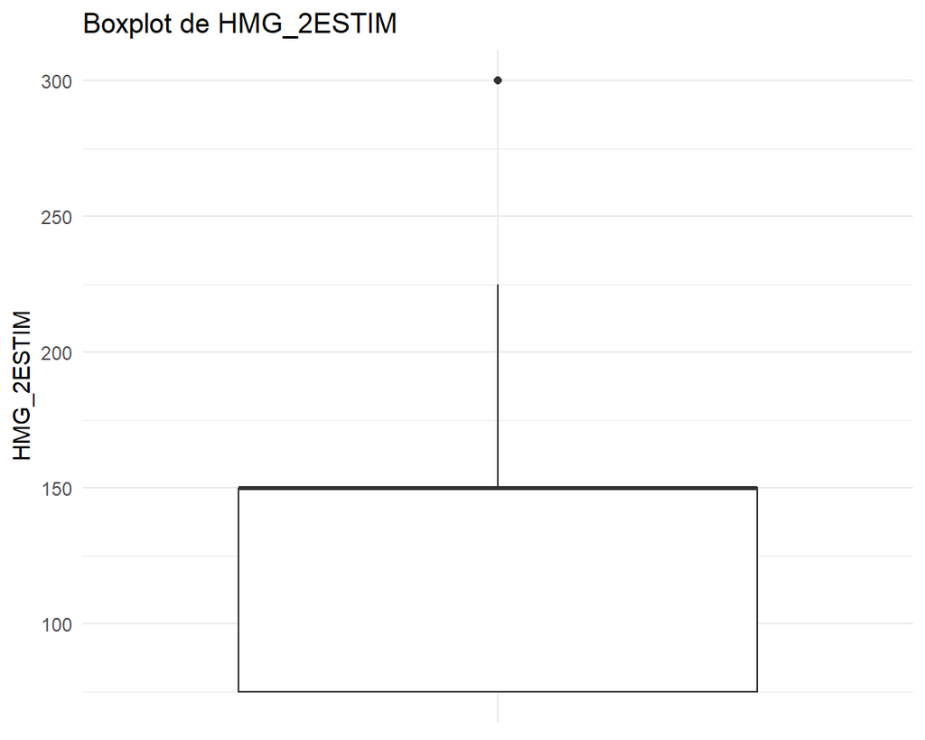

### Boxplot Número de Blastos de buena Calidad (2ESTIM)

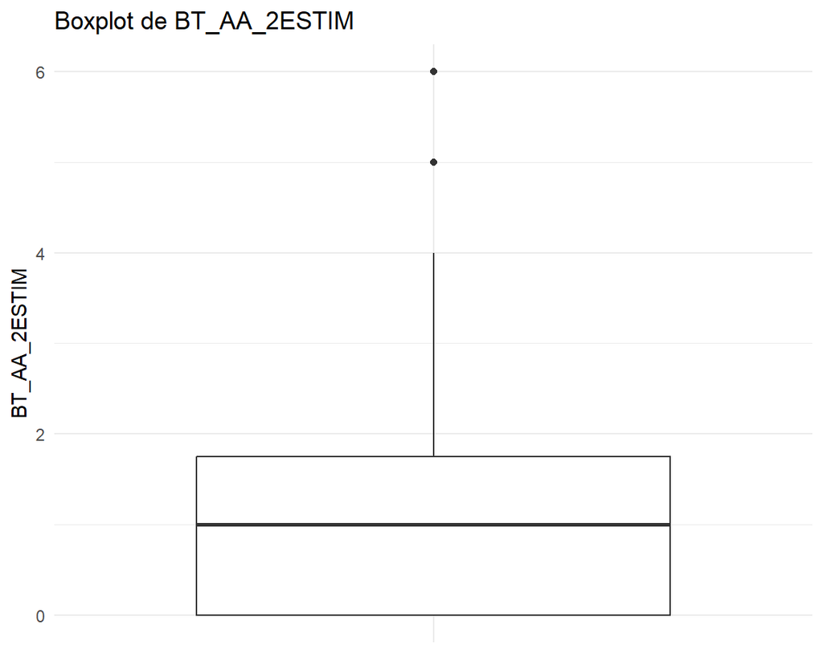

### Boxplot CONG (2ESTIM)

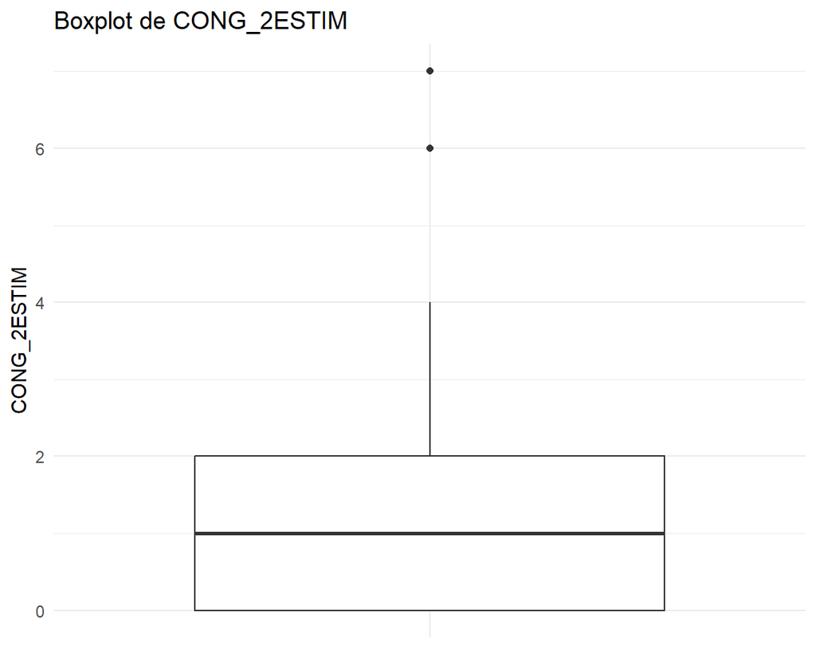

# Discusión de los resultados del pre-procesamiento

## ## Column 1

### Resultados

Se evidencia en el `data.frame` de la columna adyacente la eliminación de los valores faltantes (`NA`), así como la recodificación de las variables categóricas conforme a las especificaciones de los trabajadores de la clínica de fertilidad, incluyendo la corrección de valores atípicos.

La imputación de los valores faltantes mediante métodos apropiados ha preservado la representatividad de las muestras que inicialmente presentaban NA, lo cual es de suma importancia para el análisis de la variable de estudio. Esta medida resulta crítica dada la naturaleza limitada de los conjuntos de datos clínicos, donde es fundamental aprovechar todos los datos disponibles para obtener conclusiones realistas y prácticas.

## ## Columna 2

### Conjunto de datos pre-procesado final

|  | EDAD | AFC | FACTOR_MAS | FACTOR_FEM_1 | BMI | DIAS_1ESTIM | DOSIS_1ESTIM | HMG_1ESTIM | Nº_OVO_1ESTIM | MII_1ESTIM | FERTILIZ_1ESTIM | BT_AA_1ESTIM | CONG_1ESTIM | BLASTUL_1ESTIM | FET_1ESTIM | DIAS_2ESTIM | DOSIS_2ESTIM | HMG_2ESTIM | Nº_OVO_2ESTIM | MII_2ESTIM | FERTILIZ_2ESTIM | BT_AA_2ESTIM | CONG_2ESTIM | BLASTUL_2ESTIM | FET_2ESTIM | GRUPO |
| --- | --- | --- | --- | --- | --- | --- | --- | --- | --- | --- | --- | --- | --- | --- | --- | --- | --- | --- | --- | --- | --- | --- | --- | --- | --- | --- |
| 1 | 43 | 7 | NO | BR | 23 | 9 | 175 | 75 | 2 | 2 | 1 | 1 | 1 | SI | SI | 10 | 225 | 75 | 9 | 6 | 4 | 1 | 1 | SI | NO | ANTAGONISTAS |
| 2 | 38 | 6 | NO | ENDO/SI/ADENO | 26 | 8 | 225 | 75 | 7 | 4 | 3 | 0 | 2 | SI | SI | 9 | 225 | 75 | 5 | 4 | 4 | 2 | 4 | SI | NO | ANTAGONISTAS |
| 3 | 34 | 4 | NO | BR | 21 | 11 | 225 | 75 | 3 | 2 | 1 | 1 | 1 | SI | SI | 12 | 200 | 75 | 7 | 6 | 3 | 2 | 2 | SI | SI | ANTAGONISTAS |
| 4 | 32 | 6 | NO | BR | 23 | 9 | 225 | 150 | 6 | 6 | 3 | 0 | 1 | SI | NO | 7 | 225 | 150 | 10 | 5 | 5 | 2 | 4 | SI | NO | ANTAGONISTAS |
| 5 | 43 | 7 | NO | BR | 23 | 10 | 225 | 75 | 11 | 8 | 3 | 0 | 0 | NO | NO | 10 | 200 | 75 | 6 | 6 | 5 | 0 | 0 | NO | NO | ANTAGONISTAS |
| 6 | 36 | 5 | SI | BR | 22 | 12 | 225 | 150 | 4 | 4 | 2 | 0 | 0 | SI | NO | 13 | 225 | 150 | 9 | 6 | 3 | 0 | 0 | NO | NO | ANTAGONISTAS |
| 7 | 39 | 6 | NO | BR | 26 | 13 | 225 | 75 | 5 | 4 | 3 | 0 | 0 | NO | NO | 15 | 225 | 75 | 4 | 4 | 4 | 1 | 1 | SI | NO | ANTAGONISTAS |
| 8 | 40 | 5 | NO | ENDO/NO/ADENO | 24 | 8 | 150 | 150 | 5 | 4 | 3 | 1 | 2 | SI | SI | 14 | 150 | 150 | 8 | 7 | 6 | 2 | 2 | SI | SI | ANTAGONISTAS |
| 9 | 34 | 5 | SI | BR | 23 | 12 | 225 | 150 | 5 | 5 | 3 | 0 | 0 | SI | NO | 12 | 225 | 150 | 5 | 4 | 1 | 0 | 1 | SI | SI | ANTAGONISTAS |
| 10 | 38 | 10 | SI | ENDO/NO/ADENO | 21 | 8 | 300 | 150 | 5 | 5 | 4 | 2 | 2 | SI | SI | 12 | 300 | 150 | 13 | 9 | 9 | 0 | 0 | NO | NO | ANTAGONISTAS |

[output cut: 69 more lines]

# Numérica

## ## Columna 1

### Estadística Univariante Numérica

En esta página se presentan medidas representativas de las columnas de tipo numérico del dataset clínico. La estadística univariante numérica es una herramienta fundamental para explorar y comprender la estructura de los datos, permitiéndonos identificar patrones significativos como la tendencia central, la dispersión, la simetría y la forma de la distribución. Esto nos ayuda a tomar decisiones fundamentadas en base a la información obtenida.

### Descripción de las medidas del estudio

[output not shown]

## ## Columna 2

### Valores de la estadística

|  | Media | Sd | Minimo | Q1 | Mediana | Q3 | Maximo | IQR | Outliers |
| --- | --- | --- | --- | --- | --- | --- | --- | --- | --- |
| AFC | 5.7595 | 2.9361 | 0 | 4 | 5 | 6.5 | 14 | 2.5 | 9 |
| DOSIS_1ESTIM | 205.1899 | 41.7904 | 100 | 150 | 225 | 225 | 300 | 75 | 0 |
| HMG_1ESTIM | 127.2152 | 45.5011 | 75 | 75 | 150 | 150 | 300 | 75 | 2 |
| FERTILIZ_1ESTIM | 3.0506 | 1.9994 | 0 | 2 | 3 | 4 | 9 | 2 | 3 |
| BT_AA_1ESTIM | 0.5823 | 0.7614 | 0 | 0 | 0 | 1 | 3 | 1 | 2 |
| CONG_1ESTIM | 0.9747 | 1.0124 | 0 | 0 | 1 | 2 | 4 | 2 | 0 |
| DOSIS_2ESTIM | 198.4177 | 51.7857 | 75 | 150 | 225 | 225 | 300 | 75 | 0 |
| HMG_2ESTIM | 137.6582 | 45.6213 | 75 | 112.5 | 150 | 150 | 300 | 37.5 | 5 |
| BT_AA_2ESTIM | 1.0127 | 1.2454 | 0 | 0 | 1 | 1.5 | 6 | 1.5 | 4 |
| CONG_2ESTIM | 1.443 | 1.4566 | 0 | 0 | 1 | 2 | 7 | 2 | 2 |

### p1

```
 [1] "AFC"             "DOSIS_1ESTIM"    "HMG_1ESTIM"      "FERTILIZ_1ESTIM"
 [5] "BT_AA_1ESTIM"    "CONG_1ESTIM"     "DOSIS_2ESTIM"    "HMG_2ESTIM"
 [9] "BT_AA_2ESTIM"    "CONG_2ESTIM"
```